# Capstone Quiz I

Complete all **Exercises**, and submit answers to **Questions** on the Coursera platform.

This initial quiz will concern exploratory data analysis (EDA) of the Ames Housing dataset. EDA is essential when working with any source of data and helps inform modeling.

First, let us load the data:

```r
load("ames_train.Rdata")
```

```r
library(ggplot2)
library(dplyr)
library(statsr)
```

1. Which of the following are the three variables with the highest number of missing observations?
   1. `Misc.Feature`, `Fence`, `Pool.QC`
   2. `Misc.Feature`, `Alley`, `Pool.QC`
   3. `Pool.QC`, `Alley`, `Fence`
   4. `Fireplace.Qu`, `Pool.QC`, `Lot.Frontage`

```r
missing <- ames_train %>% select(Misc.Feature, Fence, Pool.QC, Alley, Fireplace.Qu, Lot.Frontage)
na_count <- sapply(missing, function(y) sum(length(which(is.na(y)))))
na_count <- data.frame(na_count)
na_count
```

```
##              na_count
## Misc.Feature      971
## Fence             798
## Pool.QC           997
## Alley             933
## Fireplace.Qu      491
## Lot.Frontage      167
```

2. How many categorical variables are coded in R as having type `int`? Change them to factors when conducting your analysis.
   1. 0
   2. 1
   3. 2
   4. 3

```r
int_fields <- ames_train %>% select_if(is.integer)
ordinal <- int_fields %>% select(MS.SubClass, PID)
head(ordinal)
```

```
## # A tibble: 6 x 2
##   MS.SubClass       PID
##         <int>     <int>
## 1          30 909176150
## 2         120 905476230
## 3          30 911128020
## 4          70 535377150
## 5          60 534177230
## 6          85 908128060
```

```r
#ord_cols <- c('MS.SubClass', 'PID')
#ames_train[ord_cols] <- lapply(ames_train[ord_cols], factor)
```

3. In terms of price, which neighborhood has the highest standard deviation?
   1. `StoneBr`
   2. `Timber`
   3. `Veenker`
   4. `NridgHt`

```r
ames_train %>%
  filter(Neighborhood %in% c("StoneBr", "Timber", "Veenker", "NridgHt")) %>%
  group_by(Neighborhood) %>%
  summarise(std = sd(price))
```

```
## # A tibble: 4 x 2
##   Neighborhood     std
##   <fct>          <dbl>
## 1 NridgHt      105089.
## 2 StoneBr      123459.
## 3 Timber        84030.
## 4 Veenker       72545.
```

4. Using scatter plots or other graphical displays, which of the following variables appears to be the best single predictor of `price`?
   1. `Lot.Area`
   2. `Bedroom.AbvGr`
   3. `Overall.Qual`
   4. `Year.Built`

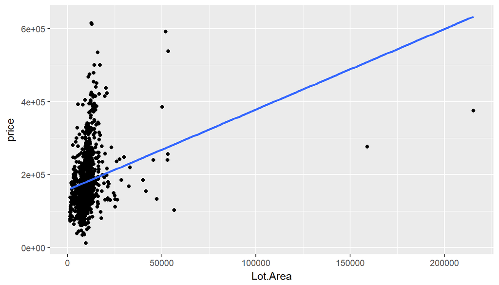

```r
#Lot.Area
ggplot(data = ames_train, aes(x= Lot.Area, y=price)) + geom_point() + stat_smooth(method='lm', se=FALSE)
```

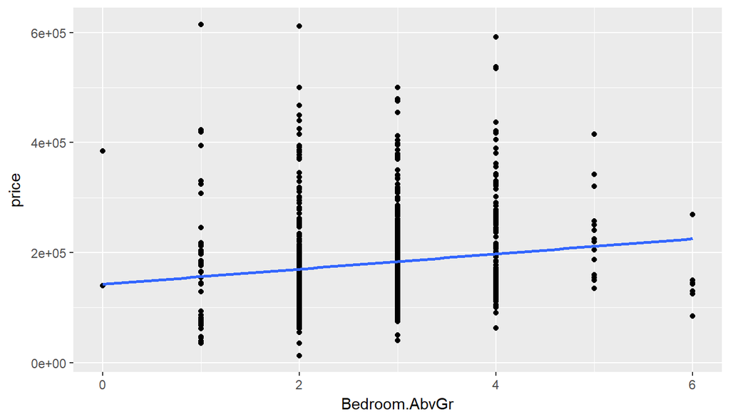

```r
#Bedroom.AbvGr
ggplot(data = ames_train, aes(x= Bedroom.AbvGr, y=price)) + geom_point() + stat_smooth(method='lm', se=FALSE)
```

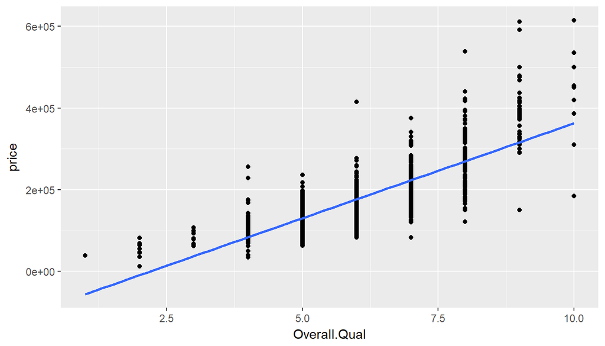

```r
#Overall.Qual
ggplot(data = ames_train, aes(x= Overall.Qual, y=price)) + geom_point() + stat_smooth(method='lm', se=FALSE)
```

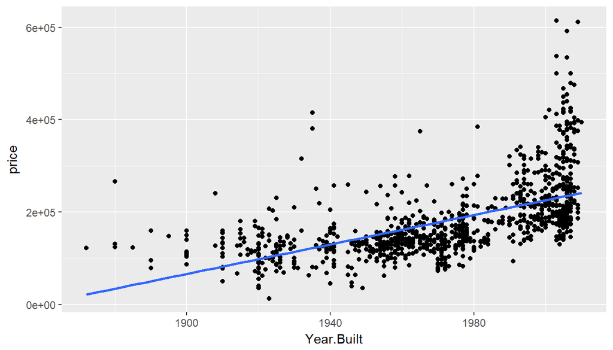

```r
#Year.Built
ggplot(data = ames_train, aes(x= Year.Built, y=price)) + geom_point() + stat_smooth(method='lm', se=FALSE)
```

5. Suppose you are examining the relationship between `price` and `area`. Which of the following variable transformations makes the relationship appear to be the most linear?
   1. Do not transform either `price` or `area`
   2. Log-transform `price` but not `area`
   3. Log-transform `area` but not `price`
   4. Log-transform both `price` and `area`

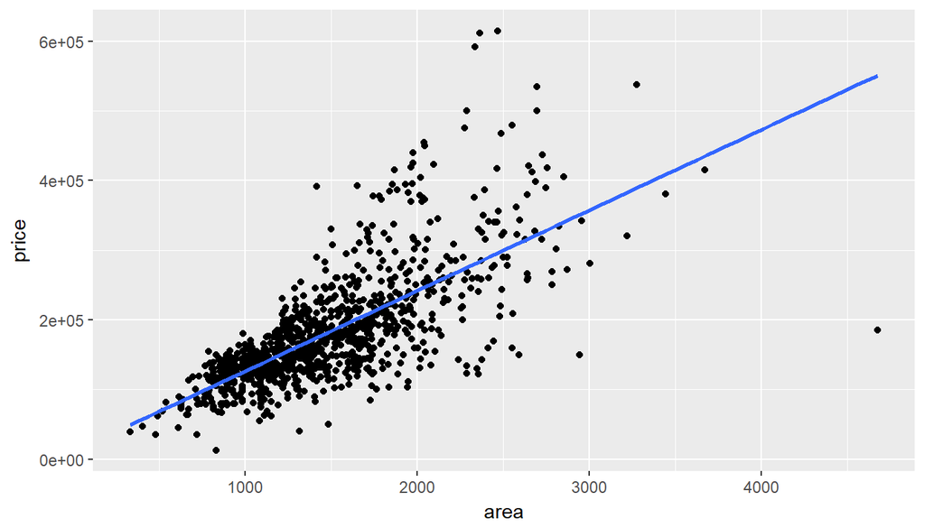

```r
#No Transform
ggplot(data = ames_train, aes(x= area, y=price)) + geom_point() + stat_smooth(method='lm', se=FALSE)
```

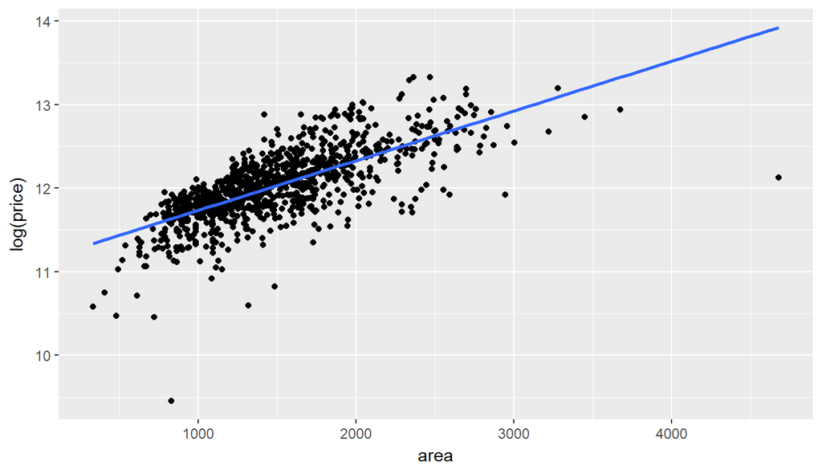

```r
#transform price but not area
ggplot(data = ames_train, aes(x= area, y=log(price))) + geom_point() + stat_smooth(method='lm', se=FALSE)
```

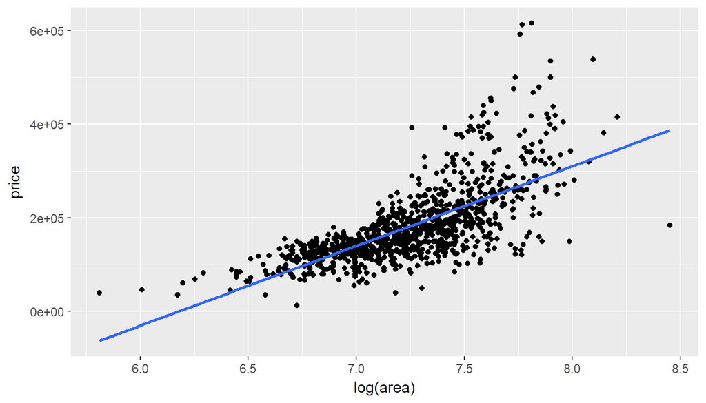

```r
#transforma area but not price
ggplot(data = ames_train, aes(x= log(area), y=price)) + geom_point() + stat_smooth(method='lm', se=FALSE)
```

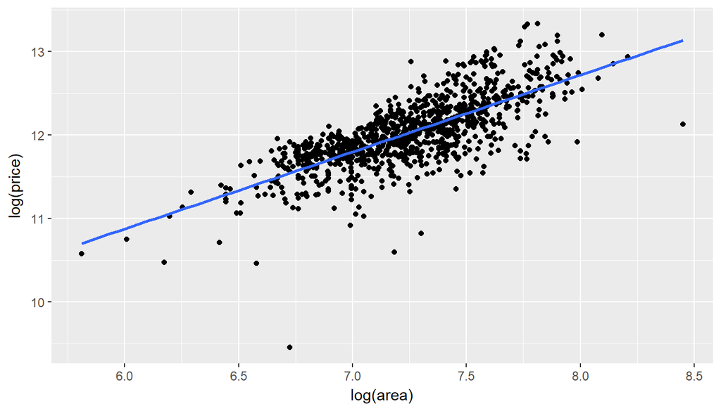

```r
#transform both
ggplot(data = ames_train, aes(x= log(area), y=log(price))) + geom_point() + stat_smooth(method='lm', se=FALSE)
```

6. Suppose that your prior for the proportion of houses that have at least one garage is Beta(9, 1). What is your posterior? Assume a beta-binomial model for this proportion.
   1. Beta(954, 46)
   2. Beta(963, 46)
   3. Beta(954, 47)
   4. Beta(963, 47)

```r
have_gar = ames_train %>% filter(!is.na(Garage.Type)) %>% summarise(count = n())
no_gar = ames_train %>% filter(is.na(Garage.Type)) %>% summarise(count = n())

b1 = 9 + have_gar
b2 = 1 + no_gar

b1
```

```
##   count
## 1   963
```

```r
b2
```

```
##   count
## 1    47
```

7. Which of the following statements is true about the dataset?
   1. Over 30 percent of houses were built after the year 1999.
   2. The median housing price is greater than the mean housing price.
   3. 21 houses do not have a basement.
   4. 4 houses are located on gravel streets.

```r
#built after 1999
after_99 = ames_train %>% filter(Year.Built > 1999) %>% summarise(count=n())
after_99/1000
```

```
##   count
## 1 0.272
```

```r
#house price
ames_train %>% summarise(mean_price = mean(price), median_price = median(price))
```

```
## # A tibble: 1 x 2
##   mean_price median_price
##        <dbl>        <dbl>
## 1    181190.       159467
```

```r
#basements, NA= no basement
summary(ames_train$Bsmt.Qual)
```

```
##        Ex   Fa   Gd   Po   TA NA's
##    1   87   28  424    1  438   21
```

```r
#gravel
summary(ames_train$Street)
```

```
## Grvl Pave
##    3  997
```

8. Test, at the $\alpha = 0.05$ level, whether homes with a garage have larger square footage than those without a garage.
   1. With a p-value near 0.000, we reject the null hypothesis of no difference.
   2. With a p-value of approximately 0.032, we reject the null hypothesis of no difference.
   3. With a p-value of approximately 0.135, we fail to reject the null hypothesis of no difference.
   4. With a p-value of approximately 0.343, we fail to reject the null hypothesis of no difference.

```r
#get datasets for with and without garages
with_gar = ames_train %>% filter(!is.na(Garage.Type))
no_gar = ames_train %>% filter(is.na(Garage.Type))

#calculate mean, std. dev, and n for each dataset
mean_with = mean(with_gar$area)
std_with = sd(with_gar$area)
n_with = nrow(with_gar)

mean_no = mean(no_gar$area)
std_no = sd(no_gar$area)
n_no = nrow(no_gar)

#calculate difference in means, SE, t_star, degrees of freedom
mean_diff = mean_with-mean_no
SE = sqrt((std_with^2/n_with) + (std_no^2/n_no))
t_star = mean_diff/SE
df = min((n_with-1), (n_no-1))

#calculate p-values
p = pt(t_star, df, lower.tail = FALSE)*2
p
```

```
## [1] 5.773316e-06
```

9. For homes with square footage greater than 2000, assume that the number of bedrooms above ground follows a Poisson distribution with rate $\lambda$. Your prior on $\lambda$ follows a Gamma distribution with mean 3 and standard deviation 1. What is your posterior mean and standard deviation for the average number of bedrooms in houses with square footage greater than 2000 square feet?
   1. Mean: 3.61, SD: 0.11
   2. Mean: 3.62, SD: 0.16
   3. Mean: 3.63, SD: 0.09
   4. Mean: 3.63, SD: 0.91

```r
#k*theta = 3
#theta * sqrt(k) = 1
#k = 9
#theta = 1/3


#k_star = k + Sum(Xi)
#theta_star = theta/(n*theta + 1)

k = 9
theta = 1/3

large_homes <- ames_train %>% filter(area > 2000) %>% select(Bedroom.AbvGr)
n_homes = length(large_homes$Bedroom.AbvGr)
sum_Xi = sum(large_homes$Bedroom.AbvGr)

k_star = k + sum_Xi
theta_star = theta/(n_homes*theta + 1)

post_mean = k_star * theta_star
post_std = theta_star * sqrt(k_star)

post_mean
```

```
## [1] 3.617021
```

```r
post_std
```

```
## [1] 0.1601644
```

10. When regressing $\log$(`price`) on $\log$(`area`), there are some outliers. Which of the following do the three most outlying points have in common?
    1. They had abnormal sale conditions.
    2. They have only two bedrooms.
    3. They have an overall quality of less than 3.
    4. They were built before 1930.

```r
library(BAS)
```

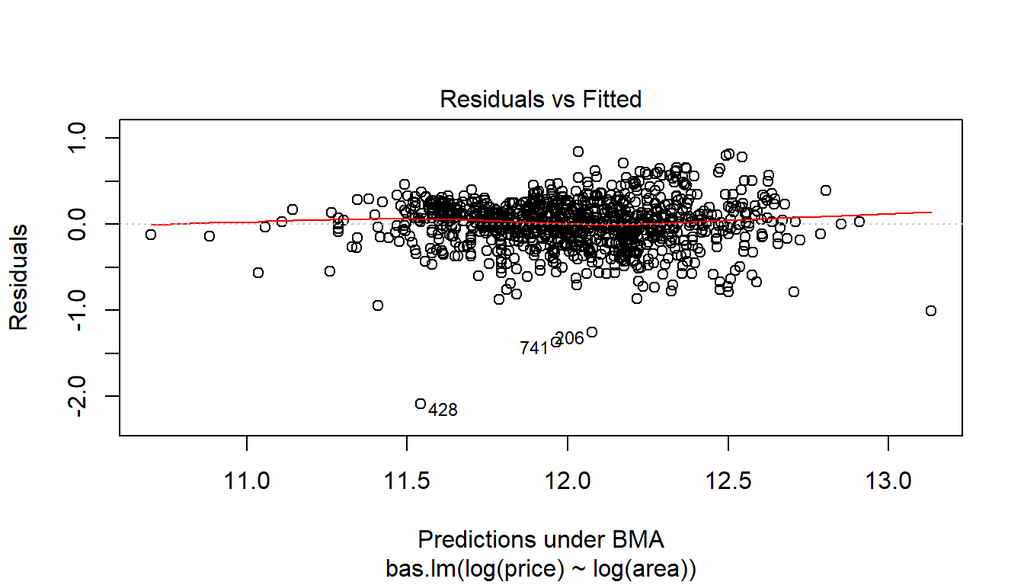

```r
lm <- bas.lm(log(price) ~ log(area), data=ames_train)
plot(lm, which=1)
```

```r
outliers <- c(206, 741, 428)
ames_train[outliers,] %>% select(Sale.Condition, Bedroom.AbvGr, Overall.Qual, Year.Built)
```

```
## # A tibble: 3 x 4
##   Sale.Condition Bedroom.AbvGr Overall.Qual Year.Built
##   <fct>                  <int>        <int>      <int>
## 1 Abnorml                    3            4       1910
## 2 Normal                     3            4       1920
## 3 Abnorml                    2            2       1923
```

11. Which of the following are reasons to log-transform `price` if used as a dependent variable in a linear regression?
    1. `price` is right-skewed.
    2. `price` cannot take on negative values.
    3. `price` can only take on integer values.
    4. Both a and b.

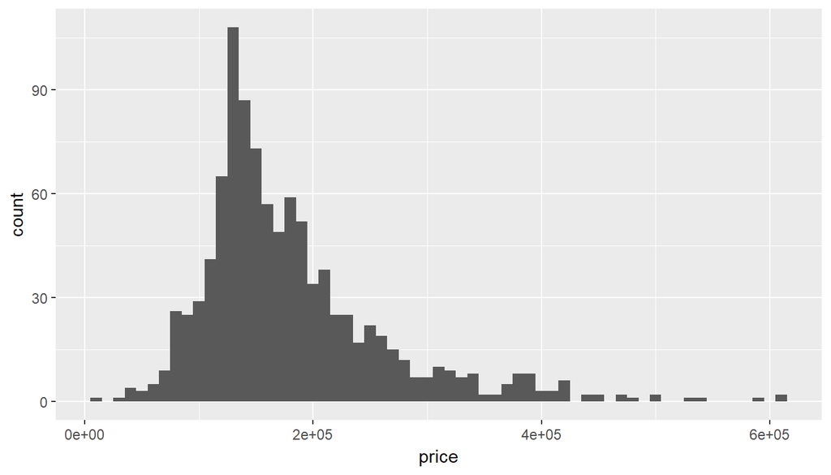

```r
ggplot(data=ames_train, aes(price)) + geom_histogram(binwidth=10000)
```

12. How many neighborhoods consist of only single-family homes? (e.g. `Bldg.Type` = `1Fam`)
    1. 0
    2. 1
    3. 2
    4. 3

```r
#select out the two fields we want
homes <- ames_train %>% select(Neighborhood, Bldg.Type)  %>% unique()
#get a count of how many different bldg types each neighborhood has
type_count = homes %>% group_by(Neighborhood) %>% summarise(count=n())
#get only the neighborhoods that have 1 type
one_type = type_count[type_count$count==1,"Neighborhood"]
#see which type those neighborhoods have
homes[homes$Neighborhood %in% one_type$Neighborhood & homes$Bldg.Type =='1Fam',]
```

```
## # A tibble: 3 x 2
##   Neighborhood Bldg.Type
##   <fct>        <fct>
## 1 Timber       1Fam
## 2 NoRidge      1Fam
## 3 ClearCr      1Fam
```

13. Using color, different plotting symbols, conditioning plots, etc., does there appear to be an association between $\log$(`area`) and the number of bedrooms above ground (`Bedroom.AbvGr`)?
    1. Yes
    2. No

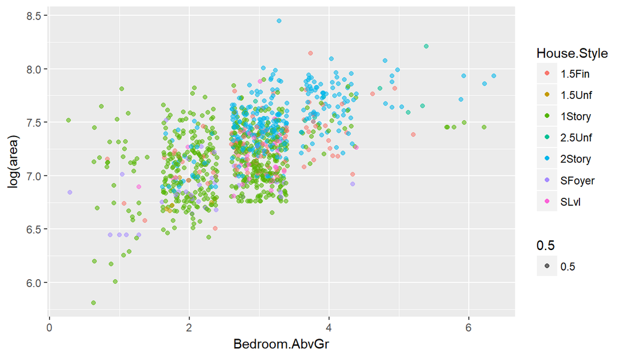

```r
ggplot(ames_train, aes(Bedroom.AbvGr, log(area))) + geom_jitter(aes(alpha=0.5, color=House.Style))
```

14. Of the people who have unfinished basements, what is the average square footage of the unfinished basement?
    1. 590.36
    2. 595.25
    3. 614.37
    4. 681.94

```r
ames_train %>% filter(Bsmt.Unf.SF>0) %>% summarize(mean = mean(na.omit(Bsmt.Unf.SF)))
```

```
## # A tibble: 1 x 1
##    mean
##   <dbl>
## 1  595.
```